# CCP 3 analysis

## 1. Summary

Present bias predicts less search, but not lower accuracy.

The effect of present bias on search is not moderated by data source (eye-tracking vs. mouselabweb) and if anything is slightly larger among the eye-tracking participants.

There is one present bias x attribute type interactions, although different than in CCP1 (effect of present bias on search is less true for annual fee than the other attributes (in CCP1 the interaction was with intro rate not annual fee).

## 2. DEEP histograms

### 2.1. Beta (Qi’s method)

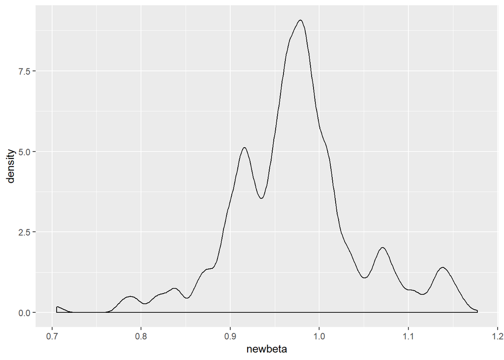

```r
ggplot(f16, aes(x = newbeta)) + geom_density()
```

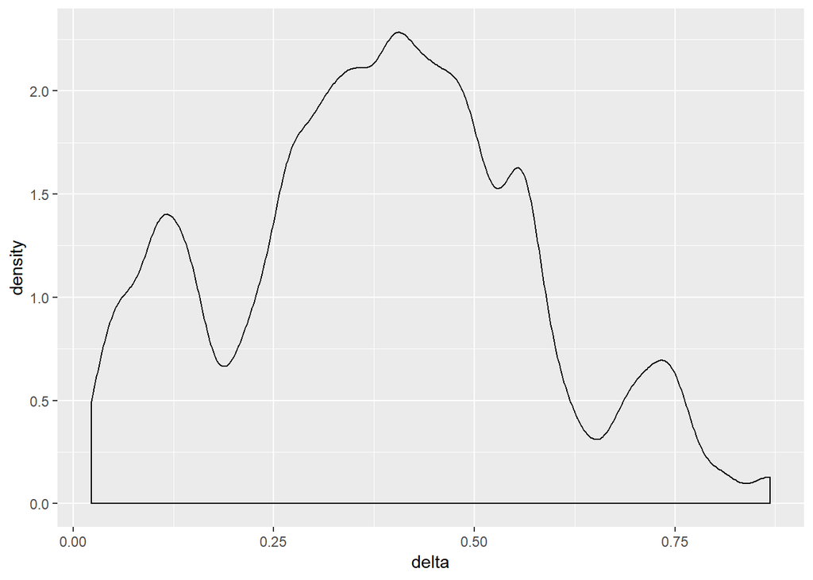

```r
ggplot(f16, aes(x = delta)) + geom_density()
```

```r
cor.test(f16$newbeta,f16$delta)
```

```
##
##  Pearson's product-moment correlation
##
## data:  f16$newbeta and f16$delta
## t = 56.867, df = 18830, p-value < 2.2e-16
## alternative hypothesis: true correlation is not equal to 0
## 95 percent confidence interval:
##  0.3705887 0.3949677
## sample estimates:
##       cor
## 0.3828449
```

## 3. Boxes opened and timing summary statistics

### 3.1. Summaries of boxes opened and time searching

```r
f16$logfixations<-log10(f16$fixations+1)

#Fixations per box (raw count)
summary(f16$fixations)
```

```
##    Min. 1st Qu.  Median    Mean 3rd Qu.    Max.
##   0.000   1.000   2.000   3.514   4.000  67.000
```

```r
#Log fixations per box (log-transformed to reduce skewness)
summary(f16$logfixations)
```

```
##    Min. 1st Qu.  Median    Mean 3rd Qu.    Max.
##  0.0000  0.3010  0.4771  0.5329  0.6990  1.8325
```

### 3.2. Histograms

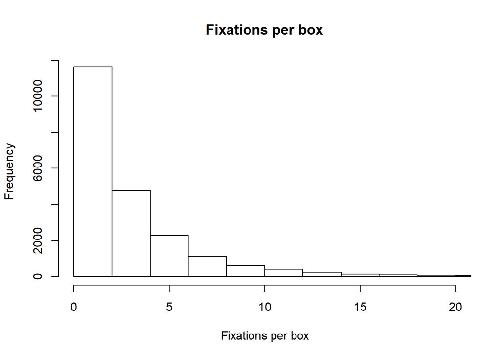

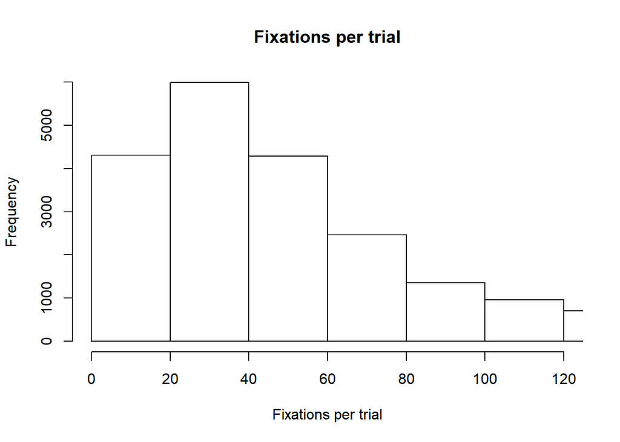

### 3.3 Skewness of variables

Suggests we should use log-transformations, since they are the least skewed. If we follow the rules from the pre-registration for determining this, use log-transformations in this study.

```r
skewness(f16$sqrtfix)
```

```
## [1] 1.242091
```

```r
skewness(f16$totalfix)
```

```
## [1] 3.672818
```

```r
skewness(f16$logfix)
```

```
## [1] -0.3024434
```

```r
skewness(f16$sqrttime)
```

```
## [1] 2.589974
```

```r
skewness(f16$searchtime)
```

```
## [1] 4.480522
```

```r
skewness(f16$logtime)
```

```
## [1] 1.52865
```

```r
skewness(f16$fixations,na.rm=TRUE)
```

```
## [1] 4.258672
```

```r
f16$sqrtfixations<-sqrt(f16$fixations)
skewness(f16$sqrtfixations,na.rm=TRUE)
```

```
## [1] 0.8987615
```

```r
skewness(f16$logfixations,na.rm=TRUE)
```

```
## [1] 0.3383586
```

## 4. Old style inferential tests (1 line per trial)

```r
f16$newbeta.c<-f16$newbeta-mean(f16$newbeta,na.rm=TRUE)
f16$delta.c<-f16$delta-mean(f16$delta,na.rm=TRUE)

m1 <- lmer(logfix ~ newbeta.c*datasource+delta.c+(1|RecordingName), data = f16, control = lmerControl(optimizer = "bobyqa", optCtrl = list(maxfun = 2e5)))
summary(m1)
```

```
## Linear mixed model fit by REML. t-tests use Satterthwaite's method [
## lmerModLmerTest]
## Formula: logfix ~ newbeta.c * datasource + delta.c + (1 | RecordingName)
##    Data: f16
## Control: lmerControl(optimizer = "bobyqa", optCtrl = list(maxfun = 2e+05))
##
## REML criterion at convergence: -5013.6
##
## Scaled residuals:
##     Min      1Q  Median      3Q     Max
## -5.4774 -0.4749  0.0154  0.4874  4.3861
##
## Random effects:
##  Groups        Name        Variance Std.Dev.
##  RecordingName (Intercept) 0.08643  0.2940
##  Residual                  0.04200  0.2049
## Number of obs: 18832, groups:  RecordingName, 250
##
## Fixed effects:
##                       Estimate Std. Error        df t value Pr(>|t|)
## (Intercept)            1.77918    0.02308 244.87388  77.088  < 2e-16 ***
## newbeta.c              0.57189    0.30026 244.87866   1.905    0.058 .
## datasource            -0.36831    0.04652 244.87154  -7.917 8.44e-14 ***
## delta.c                0.05211    0.10541 244.99648   0.494    0.621
## newbeta.c:datasource  -0.45217    0.56649 244.88244  -0.798    0.426
## ---
## Signif. codes:  0 '***' 0.001 '**' 0.01 '*' 0.05 '.' 0.1 ' ' 1
##
## Correlation of Fixed Effects:
##             (Intr) nwbt.c datsrc delt.c
## newbeta.c    0.066
## datasource  -0.585 -0.111
## delta.c     -0.035 -0.332  0.129
## nwbt.c:dtsr -0.072 -0.379  0.055 -0.015
```

```r
m2 <- lmer(logtime ~ newbeta.c*datasource+(1|RecordingName), data = f16, control = lmerControl(optimizer = "bobyqa", optCtrl = list(maxfun = 2e5)))
summary(m2)
```

```
## Linear mixed model fit by REML. t-tests use Satterthwaite's method [
## lmerModLmerTest]
## Formula: logtime ~ newbeta.c * datasource + (1 | RecordingName)
##    Data: f16
## Control: lmerControl(optimizer = "bobyqa", optCtrl = list(maxfun = 2e+05))
##
## REML criterion at convergence: 3557.8
##
## Scaled residuals:
##     Min      1Q  Median      3Q     Max
## -5.2550 -0.5208 -0.0300  0.5233  4.1735
##
## Random effects:
##  Groups        Name        Variance Std.Dev.
##  RecordingName (Intercept) 0.18845  0.4341
##  Residual                  0.06594  0.2568
## Number of obs: 18832, groups:  RecordingName, 250
##
## Fixed effects:
##                       Estimate Std. Error        df t value Pr(>|t|)
## (Intercept)            3.63312    0.03402 245.65805 106.787   <2e-16 ***
## newbeta.c              0.76010    0.41774 245.66784   1.820    0.070 .
## datasource            -3.66289    0.06804 245.65805 -53.831   <2e-16 ***
## newbeta.c:datasource   0.13603    0.83548 245.66784   0.163    0.871
## ---
## Signif. codes:  0 '***' 0.001 '**' 0.01 '*' 0.05 '.' 0.1 ' ' 1
##
## Correlation of Fixed Effects:
##             (Intr) nwbt.c datsrc
## newbeta.c    0.057
## datasource  -0.586 -0.072
## nwbt.c:dtsr -0.072 -0.407  0.057
```

```r
#still need to run a robustness test excluding search time outliers, since there were a couple very extreme search times.
```

### 4.2. Present bias does not predict accuracy in this study.

```r
m3 <- glmer(correct ~ newbeta.c*datasource+delta.c+(1|RecordingName), data = f16, family=binomial,control = glmerControl(optimizer = "bobyqa", optCtrl = list(maxfun = 2e5)))
summary(m3)
```

```
## Generalized linear mixed model fit by maximum likelihood (Laplace
##   Approximation) [glmerMod]
##  Family: binomial  ( logit )
## Formula: correct ~ newbeta.c * datasource + delta.c + (1 | RecordingName)
##    Data: f16
## Control:
## glmerControl(optimizer = "bobyqa", optCtrl = list(maxfun = 2e+05))
##
##      AIC      BIC   logLik deviance df.resid
##  14974.6  15021.7  -7481.3  14962.6    18826
##
## Scaled residuals:
##      Min       1Q   Median       3Q      Max
## -2.63340 -0.57753 -0.05335  0.44941  2.64024
##
## Random effects:
##  Groups        Name        Variance Std.Dev.
##  RecordingName (Intercept) 18.04    4.247
## Number of obs: 18832, groups:  RecordingName, 250
##
## Fixed effects:
##                      Estimate Std. Error z value Pr(>|z|)
## (Intercept)           -0.7276     0.3367  -2.161   0.0307 *
## newbeta.c              2.3028     3.8016   0.606   0.5447
## datasource            -0.2249     0.6727  -0.334   0.7381
## delta.c                0.1428     1.4401   0.099   0.9210
## newbeta.c:datasource  -0.5427     4.2860  -0.127   0.8992
## ---
## Signif. codes:  0 '***' 0.001 '**' 0.01 '*' 0.05 '.' 0.1 ' ' 1
##
## Correlation of Fixed Effects:
##             (Intr) nwbt.c datsrc delt.c
## newbeta.c    0.040
## datasource  -0.570 -0.087
## delta.c     -0.029 -0.353  0.125
## nwbt.c:dtsr -0.035 -0.273  0.005  0.080
```

```r
#m1b<-glmer(correct~newbeta+delta+(1|RecordingName),data=f16,family=binomial)
#summary(m1b)
```

## 5. Key Inferential Tests (16 lines per person, includes interactions with datasource and type of attribute box)

### 5.1. Mixed Models

Present bias predicts less search, and there is no significant interaction with whether it’s eye-tracking or mouse-tracking.

People clearly do examine many more boxes in eye-tracking than mouselabweb (datasource effect).

There is one interaction between beta and attribute type, however not what we find in CCP1. Luckily, these were exploratory anyway; we didn’t pre-register any interactions with attribute type.

The first model (m4) is a simpler model, with just the beta and beta x datasource (eye-tracking vs. mouse-tracking) interaction

The second model (m5) includes all interactions with type of attribute box, etc. The second model didn’t converge when tried as a Poisson (even with the “bobyqa” fix that has worked in the past); not too surprising it didn’t converge given that there are 24 predictors when including all 4 box types and all interactions with beta, delta, and datasource.

```r
f16$newbeta.c<-f16$newbeta-mean(f16$newbeta,na.rm=TRUE)
f16$delta.c<-f16$delta-mean(f16$delta,na.rm=TRUE)
#dummys already centered so removed the "-.5" from 4 lines below
f16$standard.c<-f16$dummystd
f16$intro.c<-f16$dummyintro
f16$period.c<-f16$dummyperiod
f16$annualfee.c<-f16$dummyannual

# Remade f16$attbox based on f16$f3 which is based on f16$first3
f16$attbox<-NA
f16$attbox[f16$f3=="APR"]<-"APRStandard"
f16$attbox[f16$f3=="Ann"]<-"AnnualFee"
f16$attbox[f16$f3=="iAP"]<-"IntroRate"
f16$attbox[f16$f3=="iPe"]<-"AIntroPeriod"

f16$attbox<-as.factor(f16$attbox)

##simpler model with just the interaction by datasource
m4 <- glmer(fixations ~ newbeta.c*datasource + delta.c+(1|RecordingName), data = f16, family = poisson, control = glmerControl(optimizer = "bobyqa", optCtrl = list(maxfun = 2e5)))
summary(m4)
```

```
## Generalized linear mixed model fit by maximum likelihood (Laplace
##   Approximation) [glmerMod]
##  Family: poisson  ( log )
## Formula:
## fixations ~ newbeta.c * datasource + delta.c + (1 | RecordingName)
##    Data: f16
## Control:
## glmerControl(optimizer = "bobyqa", optCtrl = list(maxfun = 2e+05))
##
##      AIC      BIC   logLik deviance df.resid
##  84460.1  84507.1 -42224.0  84448.1    18826
##
## Scaled residuals:
##     Min      1Q  Median      3Q     Max
## -4.5340 -0.8572 -0.2431  0.5704 12.5315
##
## Random effects:
##  Groups        Name        Variance Std.Dev.
##  RecordingName (Intercept) 0.4616   0.6794
## Number of obs: 18832, groups:  RecordingName, 250
##
## Fixed effects:
##                      Estimate Std. Error z value Pr(>|z|)
## (Intercept)           1.33002    0.05331  24.947  < 2e-16 ***
## newbeta.c             1.43994    0.66454   2.167   0.0302 *
## datasource           -0.79440    0.10742  -7.395 1.41e-13 ***
## delta.c               0.11621    0.24282   0.479   0.6322
## newbeta.c:datasource -1.61252    1.04032  -1.550   0.1211
## ---
## Signif. codes:  0 '***' 0.001 '**' 0.01 '*' 0.05 '.' 0.1 ' ' 1
##
## Correlation of Fixed Effects:
##             (Intr) nwbt.c datsrc delt.c
## newbeta.c    0.055
## datasource  -0.582 -0.102
## delta.c     -0.035 -0.336  0.128
## nwbt.c:dtsr -0.056 -0.311  0.041 -0.010
```

```r
##Full model with all interactions
m5 <- lmer(logfixations ~ newbeta.c*datasource*attbox+delta.c*datasource*attbox+(1|RecordingName), data = f16, control = lmerControl(optimizer = "bobyqa", optCtrl = list(maxfun = 2e5)))
summary(m5)
```

```
## Linear mixed model fit by REML. t-tests use Satterthwaite's method [
## lmerModLmerTest]
## Formula:
## logfixations ~ newbeta.c * datasource * attbox + delta.c * datasource *
##     attbox + (1 | RecordingName)
##    Data: f16
## Control: lmerControl(optimizer = "bobyqa", optCtrl = list(maxfun = 2e+05))
##
## REML criterion at convergence: -1892.8
##
## Scaled residuals:
##     Min      1Q  Median      3Q     Max
## -4.8092 -0.6327  0.0092  0.6483  3.9133
##
## Random effects:
##  Groups        Name        Variance Std.Dev.
##  RecordingName (Intercept) 0.04153  0.2038
##  Residual                  0.04994  0.2235
## Number of obs: 18832, groups:  RecordingName, 250
##
## Fixed effects:
##                                          Estimate Std. Error         df
## (Intercept)                             6.740e-01  1.671e-02  2.705e+02
## newbeta.c                               5.518e-01  2.163e-01  2.701e+02
## datasource                             -2.942e-01  3.343e-02  2.705e+02
## attboxAnnualFee                        -1.574e-01  6.179e-03  1.856e+04
## attboxAPRStandard                       3.483e-02  6.179e-03  1.856e+04
## attboxIntroRate                        -3.420e-02  6.179e-03  1.856e+04
## delta.c                                -2.262e-02  8.138e-02  2.707e+02
## newbeta.c:datasource                   -6.138e-01  4.327e-01  2.701e+02
## newbeta.c:attboxAnnualFee              -3.129e-01  7.939e-02  1.856e+04
## newbeta.c:attboxAPRStandard            -3.360e-02  7.939e-02  1.856e+04
## newbeta.c:attboxIntroRate              -2.426e-02  7.939e-02  1.856e+04
## datasource:attboxAnnualFee              1.919e-01  1.236e-02  1.856e+04
## datasource:attboxAPRStandard            1.307e-02  1.236e-02  1.856e+04
## datasource:attboxIntroRate              6.119e-02  1.236e-02  1.856e+04
## datasource:delta.c                      1.107e-01  1.628e-01  2.707e+02
## attboxAnnualFee:delta.c                 6.556e-02  3.010e-02  1.856e+04
## attboxAPRStandard:delta.c               4.132e-02  3.010e-02  1.856e+04
## attboxIntroRate:delta.c                 1.379e-02  3.010e-02  1.856e+04
```

[output cut: 18 more lines]

```
## datasource:attboxAnnualFee              15.527  < 2e-16 ***
## datasource:attboxAPRStandard             1.057   0.2903
## datasource:attboxIntroRate               4.952 7.42e-07 ***
## datasource:delta.c                       0.680   0.4969
## attboxAnnualFee:delta.c                  2.178   0.0294 *
## attboxAPRStandard:delta.c                1.373   0.1699
## attboxIntroRate:delta.c                  0.458   0.6469
## newbeta.c:datasource:attboxAnnualFee     1.286   0.1984
## newbeta.c:datasource:attboxAPRStandard   1.097   0.2725
## newbeta.c:datasource:attboxIntroRate     0.102   0.9192
## datasource:attboxAnnualFee:delta.c      -1.005   0.3150
## datasource:attboxAPRStandard:delta.c    -0.919   0.3582
## datasource:attboxIntroRate:delta.c      -0.656   0.5119
## ---
## Signif. codes:  0 '***' 0.001 '**' 0.01 '*' 0.05 '.' 0.1 ' ' 1
```

```
##
## Correlation matrix not shown by default, as p = 24 > 12.
## Use print(x, correlation=TRUE)  or
##     vcov(x)        if you need it
```

### 5.2. Plotting the relationship between beta and search for each attribute

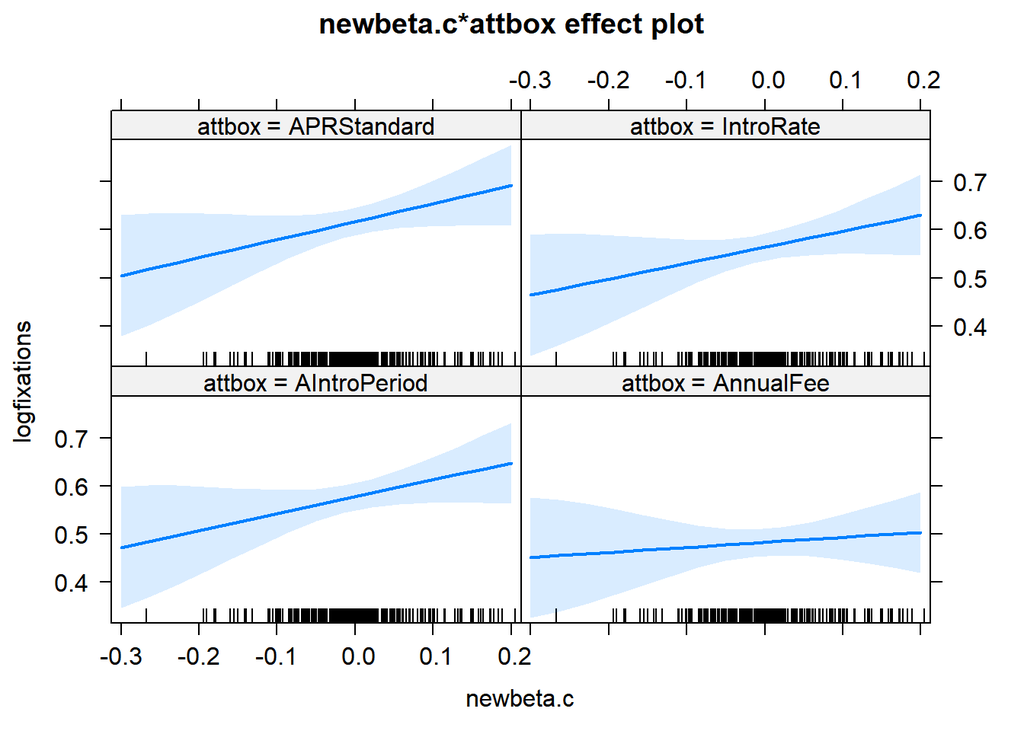

```r
plot(Effect(c("newbeta.c", "attbox"), m5))
```